[figure not shown]

# Introduction

Churn refers to customers who are lost to the business within a given timeframe. It is beneficial for businesses to identify customers who are likely to churn so that limited CRM resources can be focused where they are needed most. Understanding the factors that drive churn (such as subscription type, approaching the end of a contract, etc.) also helps the business develop a stronger customer retention strategy.

This dataset is provided by IBM. Each row represents a customer, and each column represents an attribute of that customer. The **Churn** column indicates whether a customer left during the last month, with a value of either **"Yes"** or **"No"**. IBM provides a full description of the dataset fields here: https://community.ibm.com/community/user/blogs/steven-macko/2019/07/11/telco-customer-churn-1113

## Eviroment Prep

First, install the libraries required for this workbook. If kagglehub is not already installed, install it before continuing.

```python
# Standard library
import math
from pathlib import Path
from typing import Any

# Third-party libraries
import kagglehub
import matplotlib.pyplot as plt
import numpy as np
import pandas as pd
import seaborn as sns

# Machine learning
from sklearn.ensemble import (
    GradientBoostingClassifier,
    RandomForestClassifier,
)
from sklearn.linear_model import LogisticRegression
from sklearn.metrics import (
    ConfusionMatrixDisplay,
    accuracy_score,
    auc,
    confusion_matrix,
    f1_score,
    precision_score,
    recall_score,
    roc_auc_score,
    roc_curve,
)
from sklearn.model_selection import train_test_split
from sklearn.compose import ColumnTransformer
from sklearn.impute import SimpleImputer
from sklearn.pipeline import Pipeline
from sklearn.preprocessing import OneHotEncoder, StandardScaler


from xgboost import XGBClassifier
```

## Data Load

Next, download the dataset. You can either load it directly from the source or use a locally saved CSV file.

```python
# Downloads the dataset (requires Kaggle authentication the first time)
dataset_path = kagglehub.dataset_download(
    "blastchar/telco-customer-churn"
)

# Load the CSV
csv_file = Path(dataset_path) / "WA_Fn-UseC_-Telco-Customer-Churn.csv"
dataframe = pd.read_csv(csv_file)
print(
    f"Loaded {len(dataframe):,} rows and "
    f"{len(dataframe.columns)} columns."
)
```

```
Loaded 7,043 rows and 21 columns.
```

Next, let's take a quick look at the dataset to understand its structure and the information it contains.

```python
dataframe.head(10)
```

|  | customerID | gender | SeniorCitizen | Partner | Dependents | tenure | PhoneService | MultipleLines | InternetService | OnlineSecurity | ... | DeviceProtection | TechSupport | StreamingTV | StreamingMovies | Contract | PaperlessBilling | PaymentMethod | MonthlyCharges | TotalCharges | Churn |
| --- | --- | --- | --- | --- | --- | --- | --- | --- | --- | --- | --- | --- | --- | --- | --- | --- | --- | --- | --- | --- | --- |
| 0 | 7590-VHVEG | Female | 0 | Yes | No | 1 | No | No phone service | DSL | No | ... | No | No | No | No | Month-to-month | Yes | Electronic check | 29.85 | 29.85 | No |
| 1 | 5575-GNVDE | Male | 0 | No | No | 34 | Yes | No | DSL | Yes | ... | Yes | No | No | No | One year | No | Mailed check | 56.95 | 1889.5 | No |
| 2 | 3668-QPYBK | Male | 0 | No | No | 2 | Yes | No | DSL | Yes | ... | No | No | No | No | Month-to-month | Yes | Mailed check | 53.85 | 108.15 | Yes |
| 3 | 7795-CFOCW | Male | 0 | No | No | 45 | No | No phone service | DSL | Yes | ... | Yes | Yes | No | No | One year | No | Bank transfer (automatic) | 42.30 | 1840.75 | No |
| 4 | 9237-HQITU | Female | 0 | No | No | 2 | Yes | No | Fiber optic | No | ... | No | No | No | No | Month-to-month | Yes | Electronic check | 70.70 | 151.65 | Yes |
| 5 | 9305-CDSKC | Female | 0 | No | No | 8 | Yes | Yes | Fiber optic | No | ... | Yes | No | Yes | Yes | Month-to-month | Yes | Electronic check | 99.65 | 820.5 | Yes |
| 6 | 1452-KIOVK | Male | 0 | No | Yes | 22 | Yes | Yes | Fiber optic | No | ... | No | No | Yes | No | Month-to-month | Yes | Credit card (automatic) | 89.10 | 1949.4 | No |
| 7 | 6713-OKOMC | Female | 0 | No | No | 10 | No | No phone service | DSL | Yes | ... | No | No | No | No | Month-to-month | No | Mailed check | 29.75 | 301.9 | No |
| 8 | 7892-POOKP | Female | 0 | Yes | No | 28 | Yes | Yes | Fiber optic | No | ... | Yes | Yes | Yes | Yes | Month-to-month | Yes | Electronic check | 104.80 | 3046.05 | Yes |
| 9 | 6388-TABGU | Male | 0 | No | Yes | 62 | Yes | No | DSL | Yes | ... | No | No | No | No | One year | No | Bank transfer (automatic) | 56.15 | 3487.95 | No |

10 rows × 21 columns

```python
dataframe.shape
dataframe.describe(include='all')
```

|  | customerID | gender | SeniorCitizen | Partner | Dependents | tenure | PhoneService | MultipleLines | InternetService | OnlineSecurity | ... | DeviceProtection | TechSupport | StreamingTV | StreamingMovies | Contract | PaperlessBilling | PaymentMethod | MonthlyCharges | TotalCharges | Churn |
| --- | --- | --- | --- | --- | --- | --- | --- | --- | --- | --- | --- | --- | --- | --- | --- | --- | --- | --- | --- | --- | --- |
| count | 7043 | 7043 | 7043.000000 | 7043 | 7043 | 7043.000000 | 7043 | 7043 | 7043 | 7043 | ... | 7043 | 7043 | 7043 | 7043 | 7043 | 7043 | 7043 | 7043.000000 | 7043 | 7043 |
| unique | 7043 | 2 | NaN | 2 | 2 | NaN | 2 | 3 | 3 | 3 | ... | 3 | 3 | 3 | 3 | 3 | 2 | 4 | NaN | 6531 | 2 |
| top | 7590-VHVEG | Male | NaN | No | No | NaN | Yes | No | Fiber optic | No | ... | No | No | No | No | Month-to-month | Yes | Electronic check | NaN |  | No |
| freq | 1 | 3555 | NaN | 3641 | 4933 | NaN | 6361 | 3390 | 3096 | 3498 | ... | 3095 | 3473 | 2810 | 2785 | 3875 | 4171 | 2365 | NaN | 11 | 5174 |
| mean | NaN | NaN | 0.162147 | NaN | NaN | 32.371149 | NaN | NaN | NaN | NaN | ... | NaN | NaN | NaN | NaN | NaN | NaN | NaN | 64.761692 | NaN | NaN |
| std | NaN | NaN | 0.368612 | NaN | NaN | 24.559481 | NaN | NaN | NaN | NaN | ... | NaN | NaN | NaN | NaN | NaN | NaN | NaN | 30.090047 | NaN | NaN |
| min | NaN | NaN | 0.000000 | NaN | NaN | 0.000000 | NaN | NaN | NaN | NaN | ... | NaN | NaN | NaN | NaN | NaN | NaN | NaN | 18.250000 | NaN | NaN |
| 25% | NaN | NaN | 0.000000 | NaN | NaN | 9.000000 | NaN | NaN | NaN | NaN | ... | NaN | NaN | NaN | NaN | NaN | NaN | NaN | 35.500000 | NaN | NaN |
| 50% | NaN | NaN | 0.000000 | NaN | NaN | 29.000000 | NaN | NaN | NaN | NaN | ... | NaN | NaN | NaN | NaN | NaN | NaN | NaN | 70.350000 | NaN | NaN |
| 75% | NaN | NaN | 0.000000 | NaN | NaN | 55.000000 | NaN | NaN | NaN | NaN | ... | NaN | NaN | NaN | NaN | NaN | NaN | NaN | 89.850000 | NaN | NaN |
| max | NaN | NaN | 1.000000 | NaN | NaN | 72.000000 | NaN | NaN | NaN | NaN | ... | NaN | NaN | NaN | NaN | NaN | NaN | NaN | 118.750000 | NaN | NaN |

11 rows × 21 columns

```python
dataframe.info()
dataframe.isnull().sum()
```

```
<class 'pandas.core.frame.DataFrame'>
RangeIndex: 7043 entries, 0 to 7042
Data columns (total 21 columns):
 #   Column            Non-Null Count  Dtype
---  ------            --------------  -----
 0   customerID        7043 non-null   object
 1   gender            7043 non-null   object
 2   SeniorCitizen     7043 non-null   int64
 3   Partner           7043 non-null   object
 4   Dependents        7043 non-null   object
 5   tenure            7043 non-null   int64
 6   PhoneService      7043 non-null   object
 7   MultipleLines     7043 non-null   object
 8   InternetService   7043 non-null   object
 9   OnlineSecurity    7043 non-null   object
 10  OnlineBackup      7043 non-null   object
 11  DeviceProtection  7043 non-null   object
 12  TechSupport       7043 non-null   object
 13  StreamingTV       7043 non-null   object
 14  StreamingMovies   7043 non-null   object
 15  Contract          7043 non-null   object
 16  PaperlessBilling  7043 non-null   object
 17  PaymentMethod     7043 non-null   object
 18  MonthlyCharges    7043 non-null   float64
 19  TotalCharges      7043 non-null   object
 20  Churn             7043 non-null   object
dtypes: float64(1), int64(2), object(18)
memory usage: 1.1+ MB
```

```
customerID          0
gender              0
SeniorCitizen       0
Partner             0
Dependents          0
tenure              0
PhoneService        0
MultipleLines       0
InternetService     0
OnlineSecurity      0
OnlineBackup        0
DeviceProtection    0
TechSupport         0
StreamingTV         0
StreamingMovies     0
Contract            0
PaperlessBilling    0
PaymentMethod       0
MonthlyCharges      0
TotalCharges        0
Churn               0
dtype: int64
```

We can see that most of the variables are categorical. The **Churn** column is also categorical, making this primarily a classification problem. From its description, **TotalCharges** should be a continuous numeric variable; however, it is currently stored as an `object` data type.

```python
FORCE_CONTINUOUS = {
    "TotalCharges",
}
```

Let’s create some visualizations of the data. We can plot categorical data using bar charts and continuous data using line charts.

```
Loaded 7,043 rows and 21 columns.
```

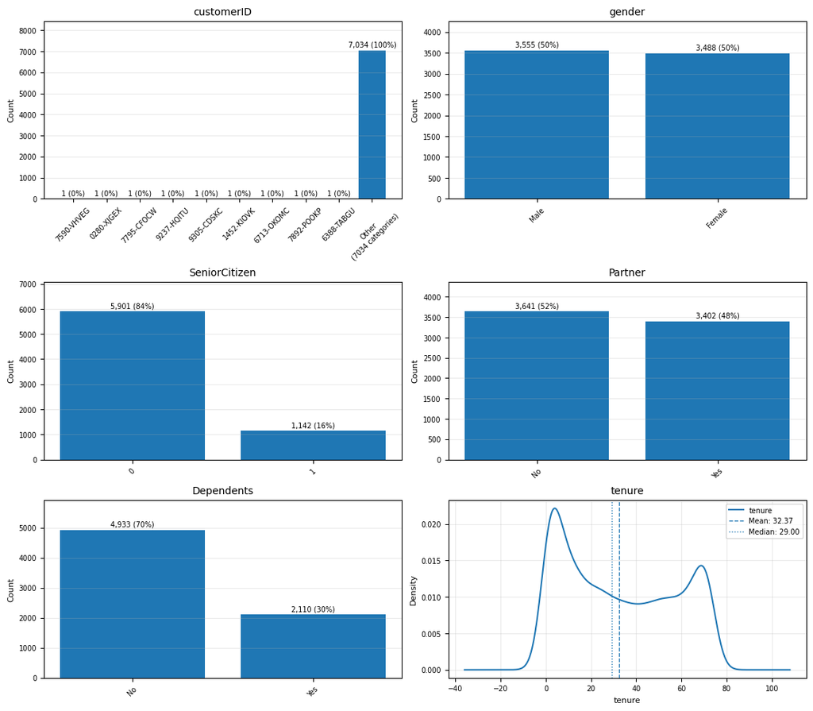

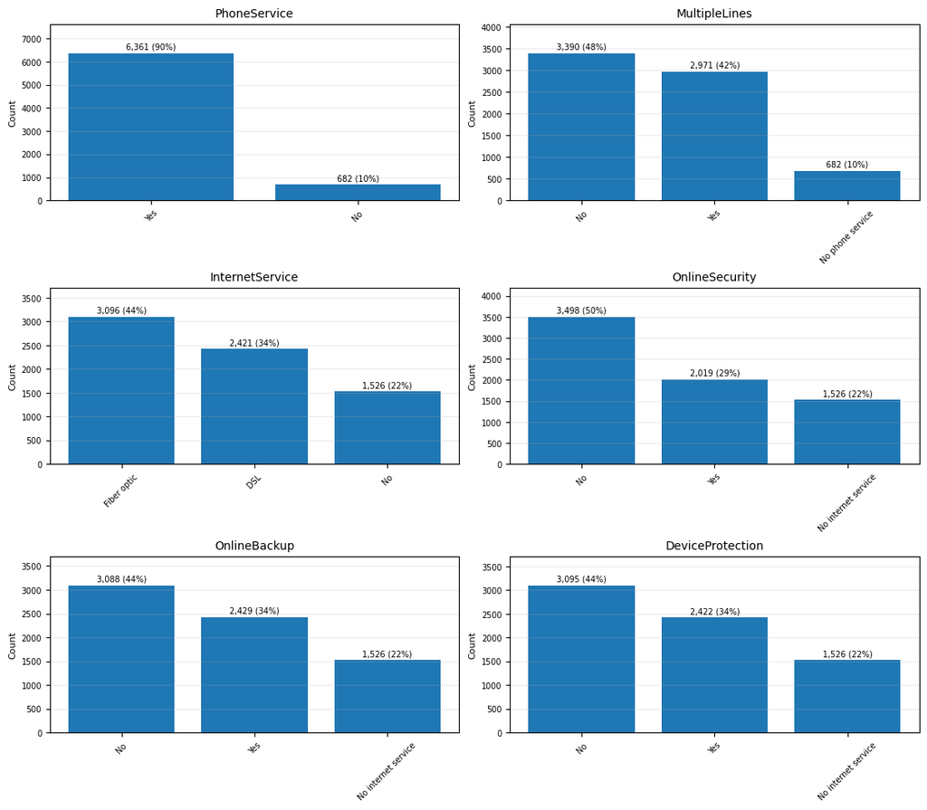

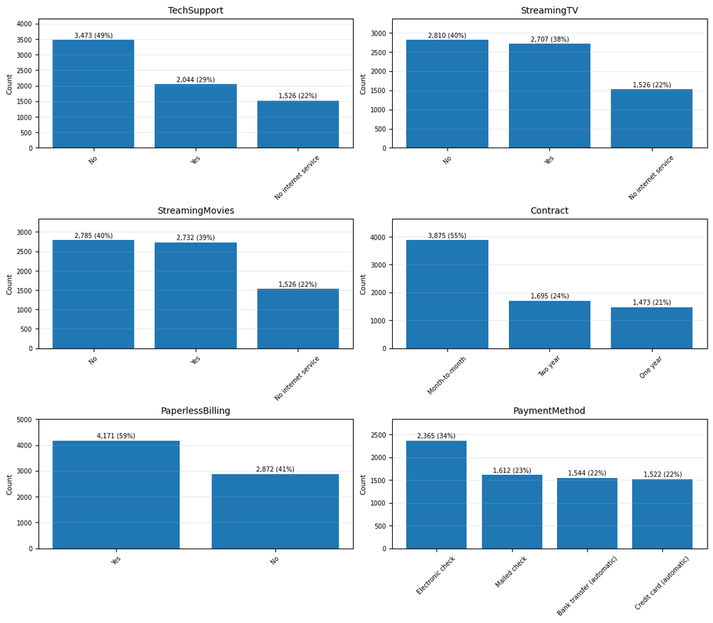

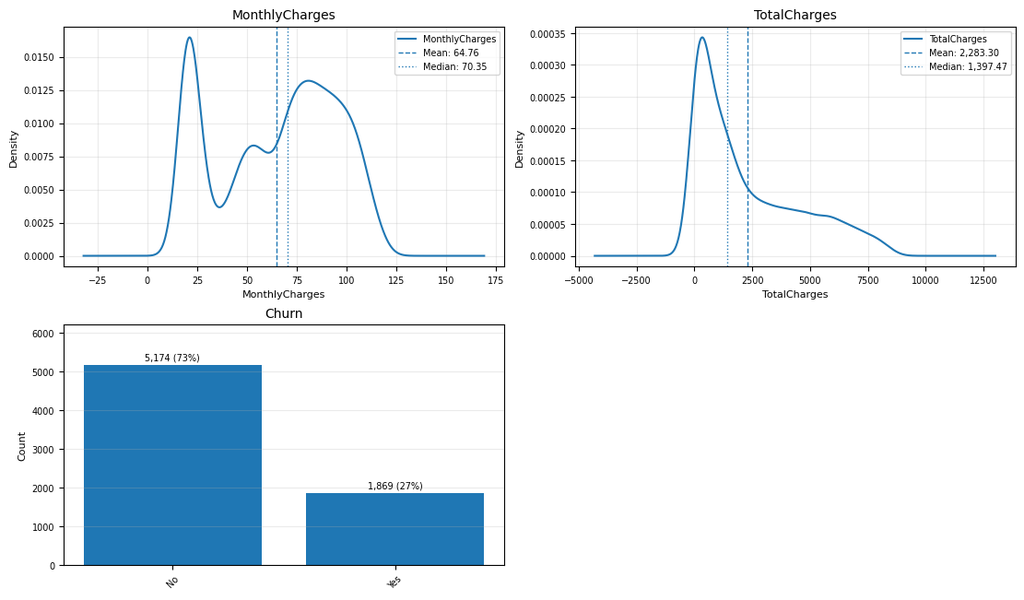

```python
def is_categorical(series):
    """
    Decide whether a column should be treated as categorical.

    Text, Boolean and category columns are categorical.

    Numeric columns with 15 or fewer unique values are also treated
    as categorical, unless they are included in FORCE_CONTINUOUS.
    """

    if series.name in FORCE_CONTINUOUS:
        return False

    non_missing = series.dropna()

    if (
        pd.api.types.is_object_dtype(series)
        or pd.api.types.is_string_dtype(series)
        or pd.api.types.is_bool_dtype(series)
        or isinstance(series.dtype, pd.CategoricalDtype)
    ):
        return True

    if pd.api.types.is_numeric_dtype(series):
        return non_missing.nunique() <= 15

    return True


def plot_categories(ax, series, column_name):
    """
    Plot categorical data as a vertical bar chart.

    Each bar label shows the absolute count and percentage,
    for example: 100 (45%).

    When there are more than 10 categories, show the 9 most common
    categories and combine the remaining categories into Other.
    """

    counts = (
        series.astype("string")
        .fillna("Missing")
        .value_counts()
    )

    total_rows = counts.sum()

    if len(counts) > 10:
        displayed = counts.iloc[:9].copy()

        number_of_other_categories = len(counts) - 9
        number_of_other_rows = counts.iloc[9:].sum()

        displayed.loc[
            f"Other\n({number_of_other_categories} categories)"
        ] = number_of_other_rows
    else:
        displayed = counts

    percentages = displayed / total_rows * 100

    bars = ax.bar(
        displayed.index.astype(str),
        displayed.values,
    )

    labels = [
        f"{count:,} ({percentage:.0f}%)"
        for count, percentage in zip(
            displayed.values,
            percentages.values,
        )
    ]

    ax.bar_label(
        bars,
        labels=labels,
        padding=2,
        fontsize=7,
    )

    ax.set_title(
        column_name,
        fontsize=10,
    )

    ax.set_ylabel(
        "Count",
        fontsize=8,
    )

    ax.tick_params(
        axis="x",
        rotation=45,
        labelsize=7,
    )

    ax.tick_params(
        axis="y",
        labelsize=7,
    )

    ax.grid(
        axis="y",
        alpha=0.25,
    )

    # Add extra space above the bars for the labels.
    if displayed.max() > 0:
        ax.set_ylim(
            0,
            displayed.max() * 1.20,
        )


def plot_continuous(ax, series, column_name):
    """
    Plot continuous numeric data as a density wave.

    Non-numeric values, including blank TotalCharges values,
    are converted to missing values and ignored.
    """

    values = pd.to_numeric(
        series,
        errors="coerce",
    ).dropna()

    if len(values) < 2 or values.nunique() < 2:
        ax.set_visible(False)
        return

    try:
        values.plot.kde(
            ax=ax,
            linewidth=1.5,
        )

    except Exception:
        # Use a histogram if a density curve cannot be created.
        ax.hist(
            values,
            bins=20,
            density=True,
            alpha=0.6,
        )

    mean_value = values.mean()
    median_value = values.median()

    ax.axvline(
        mean_value,
        linestyle="--",
        linewidth=1,
        label=f"Mean: {mean_value:,.2f}",
    )

    ax.axvline(
        median_value,
        linestyle=":",
        linewidth=1,
        label=f"Median: {median_value:,.2f}",
    )

    ax.set_title(
        column_name,
        fontsize=10,
    )

    ax.set_xlabel(
        column_name,
        fontsize=8,
    )

    ax.set_ylabel(
        "Density",
        fontsize=8,
    )

    ax.tick_params(
        axis="both",
        labelsize=7,
    )

    ax.grid(
        alpha=0.25,
    )

    ax.legend(
        fontsize=7,
    )

def visualise_csv(dataframe):
    print(
        f"Loaded {len(dataframe):,} rows and "
        f"{len(dataframe.columns)} columns."
    )

    number_of_graph_columns = 2
    graphs_per_figure = 6

    for start_index in range(
        0,
        len(dataframe.columns),
        graphs_per_figure,
    ):
        selected_columns = dataframe.columns[
            start_index:start_index + graphs_per_figure
        ]

        number_of_graph_rows = math.ceil(
            len(selected_columns) / number_of_graph_columns
        )

        fig, axes = plt.subplots(
            number_of_graph_rows,
            number_of_graph_columns,
            figsize=(11, number_of_graph_rows * 3.2),
            constrained_layout=True,
        )

        axes = np.atleast_1d(axes).ravel()

        for index, column_name in enumerate(selected_columns):
            ax = axes[index]
            series = dataframe[column_name]

            if series.dropna().empty:
                ax.set_visible(False)
                continue

            if is_categorical(series):
                plot_categories(
                    ax=ax,
                    series=series,
                    column_name=column_name,
                )
            else:
                plot_continuous(
                    ax=ax,
                    series=series,
                    column_name=column_name,
                )

        for unused_index in range(
            len(selected_columns),
            len(axes),
        ):
            axes[unused_index].set_visible(False)

        plt.show()
        plt.close(fig)

    return dataframe


# Load the CSV, display the charts and keep the data available as df.
df = visualise_csv(dataframe)
```

We can see that 27% of customers churn. Most categorical variables have only 2–4 unique values, with the exception of Customer ID, which should be dropped as it is simply an identifier and is unlikely to provide predictive value.

We can also begin to identify some trends. For example, non-senior citizens appear to churn less frequently. In contrast, gender does not appear to be a strong predictor of churn when considered in isolation, which is broadly what we might expect.

## Transforming the data set.

We can split the data into training, validation, and test sets.

```python
# ============================================================
# Separate features (X) and target (y)
# ============================================================

TARGET_COLUMN = "Churn"

# X contains all predictor variables
X = df.drop(columns=[TARGET_COLUMN]).copy()

y = (df[TARGET_COLUMN])

# ============================================================
# Split into training, validation and testing datasets
# ============================================================

# First split:
# 70% Training
# 30% Temporary
X_train, X_temp, y_train, y_temp = train_test_split(
    X,
    y,
    test_size=0.30,
    random_state=42,
    stratify=y,
)

# Second split:
# Split the remaining 30% into
# 15% Validation and 15% Testing
X_validation, X_test, y_validation, y_test = train_test_split(
    X_temp,
    y_temp,
    test_size=0.50,
    random_state=42,
    stratify=y_temp,
)

# ============================================================
# Display dataset sizes
# ============================================================

print("Full dataset")
print(f"X shape: {X.shape}")
print(f"y shape: {y.shape}")

print("\nTraining dataset")
print(f"X_train shape: {X_train.shape}")
print(f"y_train shape: {y_train.shape}")

print("\nValidation dataset")
print(f"X_validation shape: {X_validation.shape}")
print(f"y_validation shape: {y_validation.shape}")

print("\nTesting dataset")
print(f"X_test shape: {X_test.shape}")
print(f"y_test shape: {y_test.shape}")

print("\nTarget distribution (Overall)")
print(y.value_counts())

print("\nTarget distribution (Training)")
print(y_train.value_counts())

print("\nTarget distribution (Validation)")
print(y_validation.value_counts())

print("\nTarget distribution (Testing)")
print(y_test.value_counts())
```

```
Full dataset
X shape: (7043, 20)
y shape: (7043,)

Training dataset
X_train shape: (4930, 20)
y_train shape: (4930,)

Validation dataset
X_validation shape: (1056, 20)
y_validation shape: (1056,)

Testing dataset
X_test shape: (1057, 20)
y_test shape: (1057,)

Target distribution (Overall)
Churn
No     5174
Yes    1869
Name: count, dtype: int64

Target distribution (Training)
Churn
No     3622
Yes    1308
Name: count, dtype: int64

Target distribution (Validation)
Churn
No     776
Yes    280
Name: count, dtype: int64

Target distribution (Testing)
Churn
No     776
Yes    281
Name: count, dtype: int64
```

We will separate the target variable, Churn, from the feature set and drop Customer ID, as it does not provide meaningful predictive information. Next, we will encode the categorical variables using binary (0/1) values to represent the categories they belong to. We will also normalize the numerical variables so that they are on a comparable scale (normal distibutions with mean 0 and variance 1).

```python
import pandas as pd


def preprocess_data(
    X: pd.DataFrame,
    y: pd.Series,
    *,
    force_continuous: set[str] | None = None,
    top_n_categories: int = 10,
) -> tuple[pd.DataFrame, pd.Series]:
    """
    Preprocess feature and target data.

    Processing steps:
    - Converts target values equal to "Yes" into 1 and all others into 0.
    - Treats strings, objects, booleans, and categorical columns as categorical.
    - Treats numeric columns with 15 or fewer distinct values as categorical.
    - Retains only the most common categories in each categorical column.
    - Replaces remaining categories with "Other".
    - One-hot encodes categorical columns.
    - Median-imputes and standardises continuous columns.

    Parameters
    ----------
    X:
        Raw feature dataset.

    y:
        Raw target variable.

    force_continuous:
        Column names that should always be treated as continuous.

    top_n_categories:
        Maximum number of original categories retained in each
        categorical column.

    Returns
    -------
    X_processed:
        Fully numeric processed feature dataset.

    y_processed:
        Binary target variable where "Yes" is 1 and every other
        value is 0.
    """

    print(X.columns)
    X = X.drop(columns=["customerID"], errors="ignore")
    print(X.columns)

    if not isinstance(X, pd.DataFrame):
        raise TypeError("X must be a pandas DataFrame.")

    if not isinstance(y, pd.Series):
        y = pd.Series(y, index=X.index)

    if len(X) != len(y):
        raise ValueError("X and y must contain the same number of rows.")

    if top_n_categories < 1:
        raise ValueError("top_n_categories must be at least 1.")

    force_continuous = set(force_continuous or {"TotalCharges"})

    X_raw = X.copy()
    y_raw = y.copy()


    y_processed = (
        y_raw.astype("string")
        .str.strip()
        .str.lower()
        .eq("yes")
        .astype(int)
    )

    categorical_columns = []
    continuous_columns = []

    for column_name in X_raw.columns:
        series = X_raw[column_name]

        if column_name in force_continuous:
            continuous_columns.append(column_name)

        elif (
            pd.api.types.is_object_dtype(series)
            or pd.api.types.is_string_dtype(series)
            or pd.api.types.is_bool_dtype(series)
            or isinstance(series.dtype, pd.CategoricalDtype)
        ):
            categorical_columns.append(column_name)

        elif pd.api.types.is_numeric_dtype(series):
            if series.nunique(dropna=True) <= 15:
                categorical_columns.append(column_name)
            else:
                continuous_columns.append(column_name)

        else:
            categorical_columns.append(column_name)

    categorical_data = pd.DataFrame(index=X_raw.index)

    for column_name in categorical_columns:
        values = (
            X_raw[column_name]
            .astype("string")
            .fillna("Missing")
            .str.strip()
        )

        top_categories = (
            values.value_counts()
            .head(top_n_categories)
            .index
        )

        categorical_data[column_name] = values.where(
            values.isin(top_categories),
            "Other",
        )

    categorical_encoded = pd.get_dummies(
        categorical_data,
        prefix=categorical_columns,
        prefix_sep="__",
        drop_first=True,
        dtype=int,
    )

    continuous_standardised = pd.DataFrame(index=X_raw.index)

    for column_name in continuous_columns:
        values = pd.to_numeric(
            X_raw[column_name],
            errors="coerce",
        )

        median_value = values.median()

        # Handles columns where every value is missing or non-numeric.
        if pd.isna(median_value):
            median_value = 0.0

        values = values.fillna(median_value)

        mean_value = values.mean()
        standard_deviation = values.std(ddof=0)

        if standard_deviation == 0 or pd.isna(standard_deviation):
            standardised_values = pd.Series(
                0.0,
                index=values.index,
            )
        else:
            standardised_values = (
                values - mean_value
            ) / standard_deviation

        continuous_standardised[column_name] = standardised_values

    X_processed = pd.concat(
        [
            continuous_standardised,
            categorical_encoded,
        ],
        axis=1,
    ).astype(float)

    return X_processed, y_processed
```

```python
X_train, y_train= (
    preprocess_data(
        X=X_train,
        y=y_train,
    )
)


X_validation, y_validation = (
    preprocess_data(
        X=X_validation,
        y=y_validation,
    )
)


X_test, y_test= (
    preprocess_data(
        X=X_test,
        y=y_test,
    )
)
```

```
Index(['customerID', 'gender', 'SeniorCitizen', 'Partner', 'Dependents',
       'tenure', 'PhoneService', 'MultipleLines', 'InternetService',
       'OnlineSecurity', 'OnlineBackup', 'DeviceProtection', 'TechSupport',
       'StreamingTV', 'StreamingMovies', 'Contract', 'PaperlessBilling',
       'PaymentMethod', 'MonthlyCharges', 'TotalCharges'],
      dtype='object')
Index(['gender', 'SeniorCitizen', 'Partner', 'Dependents', 'tenure',
       'PhoneService', 'MultipleLines', 'InternetService', 'OnlineSecurity',
       'OnlineBackup', 'DeviceProtection', 'TechSupport', 'StreamingTV',
       'StreamingMovies', 'Contract', 'PaperlessBilling', 'PaymentMethod',
       'MonthlyCharges', 'TotalCharges'],
      dtype='object')
Index(['customerID', 'gender', 'SeniorCitizen', 'Partner', 'Dependents',
       'tenure', 'PhoneService', 'MultipleLines', 'InternetService',
       'OnlineSecurity', 'OnlineBackup', 'DeviceProtection', 'TechSupport',
       'StreamingTV', 'StreamingMovies', 'Contract', 'PaperlessBilling',
       'PaymentMethod', 'MonthlyCharges', 'TotalCharges'],
      dtype='object')
Index(['gender', 'SeniorCitizen', 'Partner', 'Dependents', 'tenure',
       'PhoneService', 'MultipleLines', 'InternetService', 'OnlineSecurity',
       'OnlineBackup', 'DeviceProtection', 'TechSupport', 'StreamingTV',
       'StreamingMovies', 'Contract', 'PaperlessBilling', 'PaymentMethod',
       'MonthlyCharges', 'TotalCharges'],
      dtype='object')
Index(['customerID', 'gender', 'SeniorCitizen', 'Partner', 'Dependents',
       'tenure', 'PhoneService', 'MultipleLines', 'InternetService',
       'OnlineSecurity', 'OnlineBackup', 'DeviceProtection', 'TechSupport',
       'StreamingTV', 'StreamingMovies', 'Contract', 'PaperlessBilling',
       'PaymentMethod', 'MonthlyCharges', 'TotalCharges'],
      dtype='object')
Index(['gender', 'SeniorCitizen', 'Partner', 'Dependents', 'tenure',
       'PhoneService', 'MultipleLines', 'InternetService', 'OnlineSecurity',
       'OnlineBackup', 'DeviceProtection', 'TechSupport', 'StreamingTV',
       'StreamingMovies', 'Contract', 'PaperlessBilling', 'PaymentMethod',
       'MonthlyCharges', 'TotalCharges'],
      dtype='object')
```

Let us rank how each of these variables correlates (absolute) with churn.

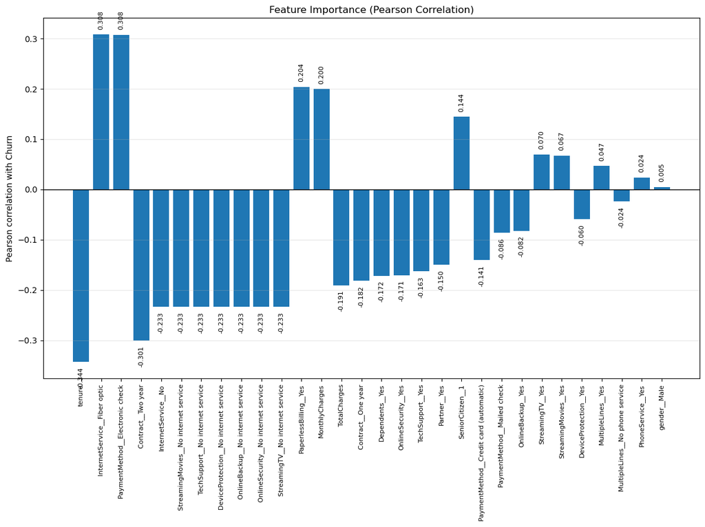

```python
# ============================================================
# Pearson correlation of every feature with the target
# ============================================================



# Correlation of every feature with y
correlations = X_train.corrwith(y_train)

# Remove any NaN values (e.g. constant columns)
correlations = correlations.dropna()

# Sort from strongest correlation to weakest
correlations = correlations.reindex(
    correlations.abs().sort_values(ascending=False).index
)

# ------------------------------------------------------------
# Plot
# ------------------------------------------------------------

plt.figure(figsize=(12, max(6, len(correlations) * 0.3)))

bars = plt.bar(
    correlations.index,
    correlations.values,
)

# Add the correlation values above each bar
for bar, value in zip(bars, correlations.values):

    plt.text(
        bar.get_x() + bar.get_width() / 2,
        value + (0.01 if value >= 0 else -0.01),
        f"{value:.3f}",
        ha="center",
        va="bottom" if value >= 0 else "top",
        fontsize=8,
        rotation=90,
    )

plt.axhline(0, color="black", linewidth=1)

plt.xticks(rotation=90, fontsize=8)
plt.ylabel("Pearson correlation with Churn")
plt.title("Feature Importance (Pearson Correlation)")
plt.grid(axis="y", alpha=0.3)

plt.tight_layout()
plt.show()
```

Customers with longer tenure tend to churn less. This makes sense, as newer customers may be more likely to leave than established, loyal customers. Similarly, customers who are on a contract tend to have lower churn rates. Customers using the fibre-optic service appear to churn more frequently, which could suggest that aspects of the product, pricing, or customer experience are less competitive. Monthly charges appear to be more strongly associated with churn than total charges. In contrast, variables such as gender, phone service, and streaming services appear to have relatively weak correlations with churn.

Next, let us examine how these variables correlate with one another.

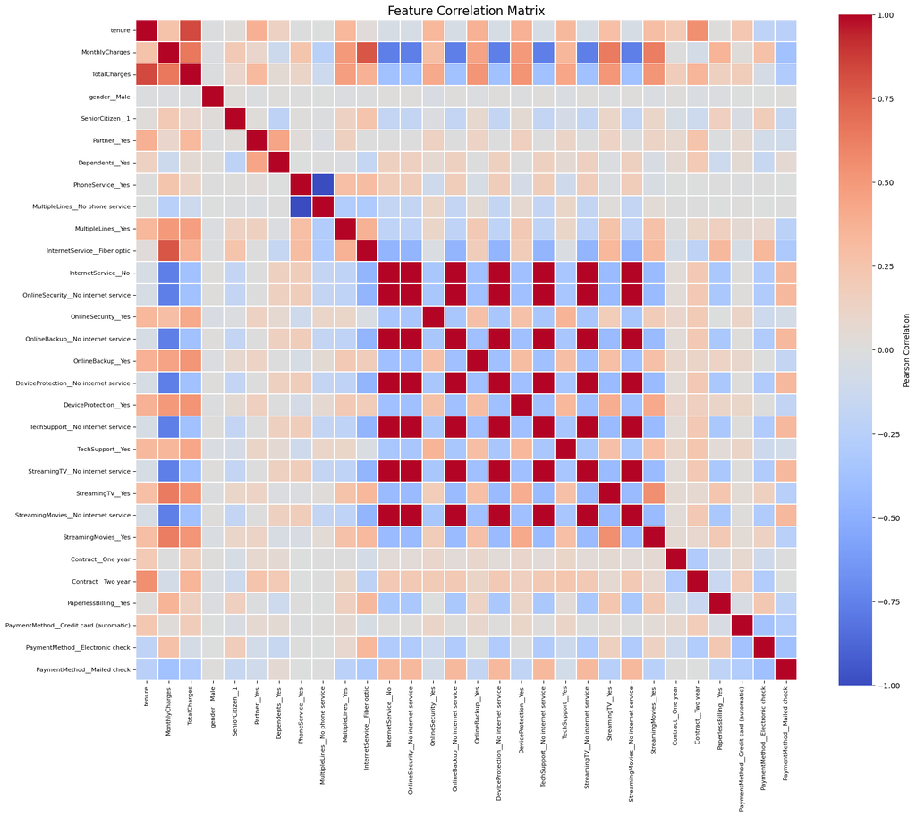

```python
# ============================================================
# Correlation Heatmap
# ============================================================

# Calculate Pearson correlation matrix
correlation_matrix = X_train.corr(method="pearson")

plt.figure(figsize=(18, 15))

sns.heatmap(
    correlation_matrix,
    cmap="coolwarm",
    center=0,
    square=True,
    linewidths=0.25,
    cbar_kws={"label": "Pearson Correlation"},
)

plt.title(
    "Feature Correlation Matrix",
    fontsize=16,
)

plt.xticks(rotation=90, fontsize=8)
plt.yticks(rotation=0, fontsize=8)

plt.tight_layout()
plt.show()
```

We can see that several categorical variables related to internet services are perfectly correlated. This is expected, as some of these features contain duplicate or redundant information, so we can remove them. Tenure is strongly correlated with total charges, which is intuitive, as customers who have been with the company longer will generally have accumulated higher total charges. Some service-related features also correlate strongly with monthly charges. Other variables, such as gender, show little positive or negative correlation with the other features.

Next, we will remove features that are perfectly correlated with other features, as well as features that have a weak correlation with Churn (absolute correlation below 0.1). We will identify which features to remove using only the training data to avoid data leakage, and then apply the same feature selection to the training, validation, and test sets.

```python
def feature_selection(
    X: pd.DataFrame,
    y: pd.Series,
    *,
    min_target_correlation: float = 0.10,
    perfect_correlation: float = 1.0,
) -> list[str]:
    """
    Determine which feature columns to keep.

    This function should be run on the TRAINING DATA ONLY.

    Returns
    -------
    list[str]
        Names of the columns to keep.
    """

    # ---------------------------------------------------------
    # 1. Remove features with weak correlation to the target
    # ---------------------------------------------------------
    target_correlations = X.corrwith(y)

    weak_features = target_correlations[
        target_correlations.abs() < min_target_correlation
    ].index.tolist()

    columns_to_keep = [
        column
        for column in X.columns
        if column not in weak_features
    ]

    # ---------------------------------------------------------
    # 2. Check remaining features for perfect correlation
    # ---------------------------------------------------------
    X_filtered = X[columns_to_keep]

    corr_matrix = X_filtered.corr().abs()

    np.fill_diagonal(
        corr_matrix.values,
        0
    )

    duplicate_features = set()
    columns = corr_matrix.columns.tolist()

    for i in range(len(columns)):
        for j in range(i + 1, len(columns)):

            if np.isclose(
                corr_matrix.iloc[i, j],
                perfect_correlation
            ):
                duplicate_features.add(
                    columns[j]
                )

    # ---------------------------------------------------------
    # 3. Final list of selected columns
    # ---------------------------------------------------------
    columns_to_keep = [
        column
        for column in columns_to_keep
        if column not in duplicate_features
    ]

    return columns_to_keep

def feature_filter(
    X: pd.DataFrame,
    columns_to_keep: list[str],
) -> pd.DataFrame:
    """
    Filter a feature dataframe to the selected columns.

    Parameters
    ----------
    X : pd.DataFrame
        Dataset to filter.

    columns_to_keep : list[str]
        Columns learned from the training data.

    Returns
    -------
    pd.DataFrame
        Filtered dataframe with columns in the same order
        as columns_to_keep.
    """

    missing_columns = [
        column
        for column in columns_to_keep
        if column not in X.columns
    ]

    if missing_columns:
        raise ValueError(
            "The following selected features are missing "
            f"from the dataset: {missing_columns}"
        )

    return X.loc[:, columns_to_keep].copy()
```

```python
# ============================================================
# FEATURE SELECTION
# Learn selected features from TRAINING DATA ONLY
# ============================================================

selected_features = feature_selection(
    X=X_train,
    y=y_train,
)

print(f"Original number of features: {X_train.shape[1]}")
print(f"Selected number of features: {len(selected_features)}")

print("\nSelected features:")
for feature in selected_features:
    print(feature)


# ============================================================
# FEATURE FILTERING
# Apply the SAME selected features to every dataset
# ============================================================

X_train = feature_filter(
    X_train,
    selected_features,
)

X_validation = feature_filter(
    X_validation,
    selected_features,
)

X_test = feature_filter(
    X_test,
    selected_features,
)


# ============================================================
# VERIFY
# ============================================================

assert list(X_train.columns) == list(X_validation.columns)
assert list(X_train.columns) == list(X_test.columns)

print("\nFinal shapes:")
print("X_train      :", X_train.shape)
print("X_validation :", X_validation.shape)
print("X_test       :", X_test.shape)

print(
    "\nTrain/test columns identical:",
    X_train.columns.equals(X_test.columns)
)
```

```
Original number of features: 30
Selected number of features: 15

Selected features:
tenure
MonthlyCharges
TotalCharges
SeniorCitizen__1
Partner__Yes
Dependents__Yes
InternetService__Fiber optic
InternetService__No
OnlineSecurity__Yes
TechSupport__Yes
Contract__One year
Contract__Two year
PaperlessBilling__Yes
PaymentMethod__Credit card (automatic)
PaymentMethod__Electronic check

Final shapes:
X_train      : (4930, 15)
X_validation : (1056, 15)
X_test       : (1057, 15)

Train/test columns identical: True
```

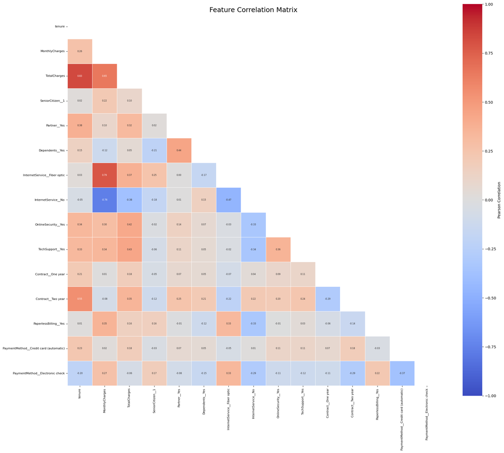

```python
# ============================================================
# Correlation Heatmap with Values
# ============================================================

correlation_matrix = X_train.corr(method="pearson")

# Only show the lower triangle
mask = np.triu(np.ones_like(correlation_matrix, dtype=bool))

plt.figure(figsize=(20, 17))

sns.heatmap(
    correlation_matrix,
    mask=mask,
    cmap="coolwarm",
    center=0,
    vmin=-1,
    vmax=1,
    square=True,
    linewidths=0.5,
    annot=True,          # Display numbers
    fmt=".2f",           # Two decimal places
    annot_kws={"size": 6},
    cbar_kws={"label": "Pearson Correlation"},
)

plt.title(
    "Feature Correlation Matrix",
    fontsize=18,
)

plt.xticks(rotation=90, fontsize=8)
plt.yticks(rotation=0, fontsize=8)

plt.tight_layout()
plt.show()
```

These will be the features we use to build and train our model.

## Build models

Let’s get a LLM to build four models using some classic machine-learning algorithms: Logistic Regression, Random Forest, Gradient Boosting, and XGBoost. We can implement and train these models in Python using standard machine-learning libraries.

```python
"""
Three-part model comparison workflow.

Part 1: build_model_specs
    Returns a list of model specifications and hyperparameters.

Part 2: run_model_comparison
    Accepts the model specification list, trains each available model,
    and returns summary tables plus fitted artefacts.

Part 3: visualise_model_results
    Accepts the returned summary tables and produces visualisations.
"""

# ============================================================
# PART 1: MODEL LIST AND HYPERPARAMETERS
# ============================================================

def build_model_specs(random_state: int = 42) -> list[dict[str, Any]]:

    model_specs: list[dict[str, Any]] = [
        {
            "name": "Logistic Regression",
            "model_class": LogisticRegression,
            "hyperparameters": {
                "max_iter": 3000,
                "random_state": random_state,
                "class_weight": "balanced",
            },
            "install_hint": None,
        },
        {
            "name": "Random Forest",
            "model_class": RandomForestClassifier,
            "hyperparameters": {
                "n_estimators": 300,
                "random_state": random_state,
                "class_weight": "balanced",
                "n_jobs": -1,
            },
            "install_hint": None,
        },
        {
            "name": "Gradient Boosting",
            "model_class": GradientBoostingClassifier,
            "hyperparameters": {
                "n_estimators": 200,
                "learning_rate": 0.05,
                "max_depth": 3,
                "random_state": random_state,
            },
            "install_hint": None,
        },
        {
            "name": "XGBoost",
            "model_class": XGBClassifier,
            "hyperparameters": {
                "n_estimators": 300,
                "learning_rate": 0.05,
                "max_depth": 4,
                "subsample": 0.8,
                "colsample_bytree": 0.8,
                "objective": "binary:logistic",
                "eval_metric": "logloss",
                "random_state": random_state,
                "n_jobs": -1,
            },
            "install_hint": None,
        },
    ]

    return model_specs
```

```python
# ============================================================
# PART 2: TRAIN MODELS AND RETURN SUMMARY DATA
# ============================================================

def run_model_comparison(
    X_train: pd.DataFrame,
    X_test: pd.DataFrame,
    y_train: pd.Series,
    y_test: pd.Series,
    model_specs: list[dict[str, Any]],
) -> dict[str, Any]:
    """
    Preprocess supplied training and testing datasets, train all
    available models, and return summary tables and fitted artefacts.

    Parameters
    ----------
    X_train : pandas DataFrame or array-like
        Training features.

    X_test : pandas DataFrame or array-like
        Testing features.

    y_train : pandas Series or array-like
        Binary training target containing 0 and 1.

    y_test : pandas Series or array-like
        Binary testing target containing 0 and 1.

    model_specs : list of dict
        Output from build_model_specs().

    Returns
    -------
    output : dict
        results:
            Model-level metric summary table.
        confusion_summary:
            Long-form confusion-matrix count table.
        skipped_models:
            Table of unavailable or failed models.
        trained_models:
            Successfully fitted estimator objects.
        confusion_matrices:
            Raw 2x2 confusion matrices by model.
        split_data:
            Preprocessed training/testing data and predictions.
        preprocessing_summary:
            Removed columns and dataset dimensions.
    """

    # ========================================================
    # Validate and prepare supplied datasets
    # ========================================================

    if not isinstance(X_train, pd.DataFrame):
        X_train = pd.DataFrame(X_train)

    if not isinstance(X_test, pd.DataFrame):
        X_test = pd.DataFrame(
            X_test,
            columns=X_train.columns,
        )

    # Work on copies so the original datasets are not modified.
    X_train = X_train.copy()
    X_test = X_test.copy()

    if len(X_train) != len(y_train):
        raise ValueError(
            "X_train and y_train must contain the same number of rows."
        )

    if len(X_test) != len(y_test):
        raise ValueError(
            "X_test and y_test must contain the same number of rows."
        )

    if list(X_train.columns) != list(X_test.columns):
        raise ValueError(
            "X_train and X_test must contain the same columns "
            "in the same order."
        )

    y_train = pd.Series(
        y_train,
        index=X_train.index,
        name="Churn",
    ).astype(int)

    y_test = pd.Series(
        y_test,
        index=X_test.index,
        name="Churn",
    ).astype(int)

    for dataset_name, target in {
        "y_train": y_train,
        "y_test": y_test,
    }.items():
        unique_targets = set(target.dropna().unique())

        if not unique_targets.issubset({0, 1}):
            raise ValueError(
                f"{dataset_name} must contain only 0 and 1. "
                f"Found: {unique_targets}"
            )

    if set(y_train.unique()) != {0, 1}:
        raise ValueError(
            "y_train must contain examples of both classes 0 and 1."
        )

    # ========================================================
    # Preprocess features using training data only
    # ========================================================

    X_train = X_train.apply(
        pd.to_numeric,
        errors="coerce",
    )

    X_test = X_test.apply(
        pd.to_numeric,
        errors="coerce",
    )

    # Remove columns that are entirely missing in the training set.
    all_missing_columns = X_train.columns[
        X_train.isna().all()
    ].tolist()

    if all_missing_columns:
        X_train = X_train.drop(columns=all_missing_columns)
        X_test = X_test.drop(columns=all_missing_columns)

    # Calculate medians from the training set only.
    training_medians = X_train.median(numeric_only=True)

    X_train = X_train.fillna(training_medians)
    X_test = X_test.fillna(training_medians)

    # Remove constant columns based on the training set only.
    constant_columns = X_train.columns[
        X_train.nunique(dropna=False) <= 1
    ].tolist()

    if constant_columns:
        X_train = X_train.drop(columns=constant_columns)
        X_test = X_test.drop(columns=constant_columns)

    if X_train.shape[1] == 0:
        raise ValueError(
            "No usable feature columns remain after preprocessing."
        )

    # ========================================================
    # Train and evaluate models
    # ========================================================

    metric_rows: list[dict[str, Any]] = []
    confusion_rows: list[dict[str, Any]] = []
    skipped_rows: list[dict[str, str]] = []

    trained_models: dict[str, Any] = {}
    confusion_matrices: dict[str, Any] = {}
    predictions: dict[str, Any] = {}
    probabilities: dict[str, Any] = {}

    for spec in model_specs:
        model_name = spec["name"]
        model_class = spec.get("model_class")
        hyperparameters = spec.get("hyperparameters", {})

        if model_class is None:
            skipped_rows.append(
                {
                    "Model": model_name,
                    "Reason": spec.get(
                        "install_hint",
                        "Model dependency is unavailable.",
                    ),
                }
            )
            continue

        try:
            model = model_class(**hyperparameters)
            model.fit(X_train, y_train)

            y_pred = (
                pd.Series(model.predict(X_test))
                .astype(int)
                .to_numpy()
            )

            if hasattr(model, "predict_proba"):
                y_probability = model.predict_proba(X_test)[:, 1]

            elif hasattr(model, "decision_function"):
                y_probability = model.decision_function(X_test)

            else:
                y_probability = None

            matrix = confusion_matrix(
                y_test,
                y_pred,
                labels=[0, 1],
            )

            tn, fp, fn, tp = matrix.ravel()

            metric_rows.append(
                {
                    "Model": model_name,
                    "Accuracy": accuracy_score(
                        y_test,
                        y_pred,
                    ),
                    "Precision": precision_score(
                        y_test,
                        y_pred,
                        zero_division=0,
                    ),
                    "Recall": recall_score(
                        y_test,
                        y_pred,
                        zero_division=0,
                    ),
                    "F1 Score": f1_score(
                        y_test,
                        y_pred,
                        zero_division=0,
                    ),
                    "ROC AUC": (
                        roc_auc_score(
                            y_test,
                            y_probability,
                        )
                        if y_probability is not None
                        else float("nan")
                    ),
                    "True Negatives": int(tn),
                    "False Positives": int(fp),
                    "False Negatives": int(fn),
                    "True Positives": int(tp),
                }
            )

            confusion_rows.extend(
                [
                    {
                        "Model": model_name,
                        "Actual": "No Churn (0)",
                        "Predicted": "No Churn (0)",
                        "Count": int(tn),
                    },
                    {
                        "Model": model_name,
                        "Actual": "No Churn (0)",
                        "Predicted": "Churn (1)",
                        "Count": int(fp),
                    },
                    {
                        "Model": model_name,
                        "Actual": "Churn (1)",
                        "Predicted": "No Churn (0)",
                        "Count": int(fn),
                    },
                    {
                        "Model": model_name,
                        "Actual": "Churn (1)",
                        "Predicted": "Churn (1)",
                        "Count": int(tp),
                    },
                ]
            )

            trained_models[model_name] = model
            confusion_matrices[model_name] = matrix
            predictions[model_name] = y_pred
            probabilities[model_name] = y_probability

        except Exception as error:
            skipped_rows.append(
                {
                    "Model": model_name,
                    "Reason": str(error),
                }
            )

    if not metric_rows:
        raise RuntimeError("None of the models could be trained.")

    # ========================================================
    # Build returned summaries
    # ========================================================

    results = (
        pd.DataFrame(metric_rows)
        .sort_values(
            by="F1 Score",
            ascending=False,
        )
        .reset_index(drop=True)
    )

    confusion_summary = pd.DataFrame(confusion_rows)

    skipped_models = pd.DataFrame(
        skipped_rows,
        columns=["Model", "Reason"],
    )

    preprocessing_summary = {
        "removed_all_missing_columns": all_missing_columns,
        "removed_constant_columns": constant_columns,
        "training_rows": len(X_train),
        "testing_rows": len(X_test),
        "feature_count": X_train.shape[1],
        "training_medians": training_medians,
    }

    split_data = {
        "X_train": X_train,
        "X_test": X_test,
        "y_train": y_train,
        "y_test": y_test,
        "predictions": predictions,
        "probabilities": probabilities,
    }

    return {
        "results": results,
        "confusion_summary": confusion_summary,
        "skipped_models": skipped_models,
        "trained_models": trained_models,
        "confusion_matrices": confusion_matrices,
        "split_data": split_data,
        "preprocessing_summary": preprocessing_summary,
    }
```

We can compare the performance of our models using confusion matrices, F1 scores, and ROC curves. These metrics will help us assess how well each model identifies customers who are likely to churn.

```python
# ============================================================
# PART 3: VISUALISE SUMMARY TABLES
# ============================================================

def visualise_model_results(
    results: pd.DataFrame,
    confusion_summary: pd.DataFrame,
    split_data: dict,
) -> None:
    """
    Create performance and error visualisations from summary tables.

    Parameters
    ----------
    results : pandas DataFrame
        Model-level results table returned by run_model_comparison().

    confusion_summary : pandas DataFrame
        Long-form confusion count table returned by
        run_model_comparison().

    split_data : dict
        Dictionary returned by run_model_comparison(). It must contain:
        - y_test
        - probabilities
    """

    required_result_columns = {
        "Model",
        "F1 Score",
        "False Positives",
        "False Negatives",
    }

    missing_result_columns = (
        required_result_columns - set(results.columns)
    )

    if missing_result_columns:
        raise ValueError(
            "results is missing required columns: "
            f"{sorted(missing_result_columns)}"
        )

    required_confusion_columns = {
        "Model",
        "Actual",
        "Predicted",
        "Count",
    }

    missing_confusion_columns = (
        required_confusion_columns
        - set(confusion_summary.columns)
    )

    if missing_confusion_columns:
        raise ValueError(
            "confusion_summary is missing required columns: "
            f"{sorted(missing_confusion_columns)}"
        )

    if "y_test" not in split_data:
        raise ValueError(
            "split_data must contain 'y_test'."
        )

    if "probabilities" not in split_data:
        raise ValueError(
            "split_data must contain 'probabilities'."
        )

    ordered_results = (
        results
        .sort_values(
            "F1 Score",
            ascending=False,
        )
        .reset_index(drop=True)
    )

    # --------------------------------------------------------
    # 1. F1 score comparison
    # --------------------------------------------------------

    fig, ax = plt.subplots(
        figsize=(11, 6)
    )

    bars = ax.bar(
        ordered_results["Model"],
        ordered_results["F1 Score"],
    )

    ax.bar_label(
        bars,
        labels=[
            f"{score:.3f}"
            for score in ordered_results["F1 Score"]
        ],
        padding=3,
        fontsize=9,
    )

    ax.set_title(
        "Model F1 Score Comparison"
    )

    ax.set_xlabel(
        "Model"
    )

    ax.set_ylabel(
        "F1 score"
    )

    ax.set_ylim(
        0,
        1.05,
    )

    ax.tick_params(
        axis="x",
        rotation=35,
    )

    ax.grid(
        axis="y",
        alpha=0.25,
    )

    plt.tight_layout()
    plt.show()

    # --------------------------------------------------------
    # 2. Confusion matrices
    # --------------------------------------------------------

    ordered_model_names = (
        ordered_results["Model"].tolist()
    )

    number_of_models = len(
        ordered_model_names
    )

    number_of_columns = 2

    number_of_rows = math.ceil(
        number_of_models
        / number_of_columns
    )

    fig, axes = plt.subplots(
        number_of_rows,
        number_of_columns,
        figsize=(
            12,
            number_of_rows * 5,
        ),
    )

    axes = (
        [axes]
        if number_of_models == 1
        else axes.ravel()
    )

    actual_order = [
        "No Churn (0)",
        "Churn (1)",
    ]

    predicted_order = [
        "No Churn (0)",
        "Churn (1)",
    ]

    for ax, model_name in zip(
        axes,
        ordered_model_names,
    ):
        model_confusion = confusion_summary[
            confusion_summary["Model"]
            == model_name
        ]

        matrix = (
            model_confusion
            .pivot(
                index="Actual",
                columns="Predicted",
                values="Count",
            )
            .reindex(
                index=actual_order,
                columns=predicted_order,
                fill_value=0,
            )
            .fillna(0)
            .astype(int)
            .to_numpy()
        )

        matrix_display = (
            ConfusionMatrixDisplay(
                confusion_matrix=matrix,
                display_labels=actual_order,
            )
        )

        matrix_display.plot(
            ax=ax,
            values_format=",d",
            colorbar=False,
        )

        model_f1 = ordered_results.loc[
            ordered_results["Model"]
            == model_name,
            "F1 Score",
        ].iloc[0]

        ax.set_title(
            f"{model_name}\n"
            f"F1 = {model_f1:.3f}"
        )

    for ax in axes[
        len(ordered_model_names):
    ]:
        ax.set_visible(False)

    fig.suptitle(
        "Confusion Matrices",
        fontsize=16,
        y=1.01,
    )

    plt.tight_layout()
    plt.show()

    # --------------------------------------------------------
    # 3. False-positive and false-negative comparison
    # --------------------------------------------------------

    error_results = ordered_results[
        [
            "Model",
            "False Positives",
            "False Negatives",
        ]
    ].copy()

    ax = (
        error_results
        .set_index("Model")
        .plot.bar(
            figsize=(11, 6)
        )
    )

    ax.set_title(
        "False Positives and False Negatives"
    )

    ax.set_xlabel(
        "Model"
    )

    ax.set_ylabel(
        "Number of predictions"
    )

    ax.tick_params(
        axis="x",
        rotation=35,
    )

    ax.grid(
        axis="y",
        alpha=0.25,
    )

    for container in ax.containers:
        ax.bar_label(
            container,
            padding=2,
            fontsize=8,
        )

    plt.tight_layout()
    plt.show()

    # --------------------------------------------------------
    # 4. ROC curves
    # --------------------------------------------------------

    y_test = split_data["y_test"]
    probabilities = split_data["probabilities"]

    fig, ax = plt.subplots(
        figsize=(10, 7)
    )

    plotted_models = 0

    for model_name in ordered_model_names:

        y_probability = probabilities.get(
            model_name
        )

        # Skip models without probability scores.
        if y_probability is None:
            print(
                f"ROC curve skipped for "
                f"{model_name}: "
                "no probability scores available."
            )
            continue

        false_positive_rate, true_positive_rate, _ = (
            roc_curve(
                y_test,
                y_probability,
            )
        )

        model_auc = auc(
            false_positive_rate,
            true_positive_rate,
        )

        # Matplotlib automatically gives every model
        # a different colour.
        ax.plot(
            false_positive_rate,
            true_positive_rate,
            linewidth=2,
            label=(
                f"{model_name} "
                f"(AUC = {model_auc:.3f})"
            ),
        )

        plotted_models += 1

    # Random-classifier reference line.
    ax.plot(
        [0, 1],
        [0, 1],
        linestyle="--",
        linewidth=1.5,
        label="Random classifier (AUC = 0.500)",
    )

    ax.set_title(
        "ROC Curve Comparison"
    )

    ax.set_xlabel(
        "False Positive Rate"
    )

    ax.set_ylabel(
        "True Positive Rate"
    )

    ax.set_xlim(
        0,
        1,
    )

    ax.set_ylim(
        0,
        1.05,
    )

    ax.grid(
        alpha=0.25,
    )

    if plotted_models > 0:
        ax.legend(
            loc="lower right"
        )

    plt.tight_layout()
    plt.show()
```

|  | Model | Accuracy | Precision | Recall | F1 Score | ROC AUC | True Negatives | False Positives | False Negatives | True Positives |
| --- | --- | --- | --- | --- | --- | --- | --- | --- | --- | --- |
| 0 | Logistic Regression | 0.746 | 0.515 | 0.794 | 0.625 | 0.842 | 566 | 210 | 58 | 223 |
| 1 | XGBoost | 0.793 | 0.627 | 0.544 | 0.583 | 0.835 | 685 | 91 | 128 | 153 |
| 2 | Gradient Boosting | 0.789 | 0.633 | 0.491 | 0.553 | 0.834 | 696 | 80 | 143 | 138 |
| 3 | Random Forest | 0.785 | 0.644 | 0.431 | 0.516 | 0.817 | 709 | 67 | 160 | 121 |

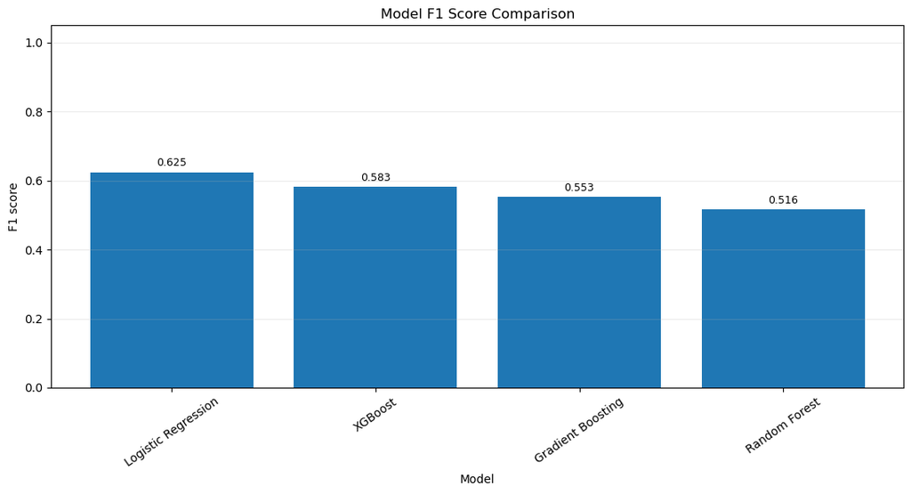

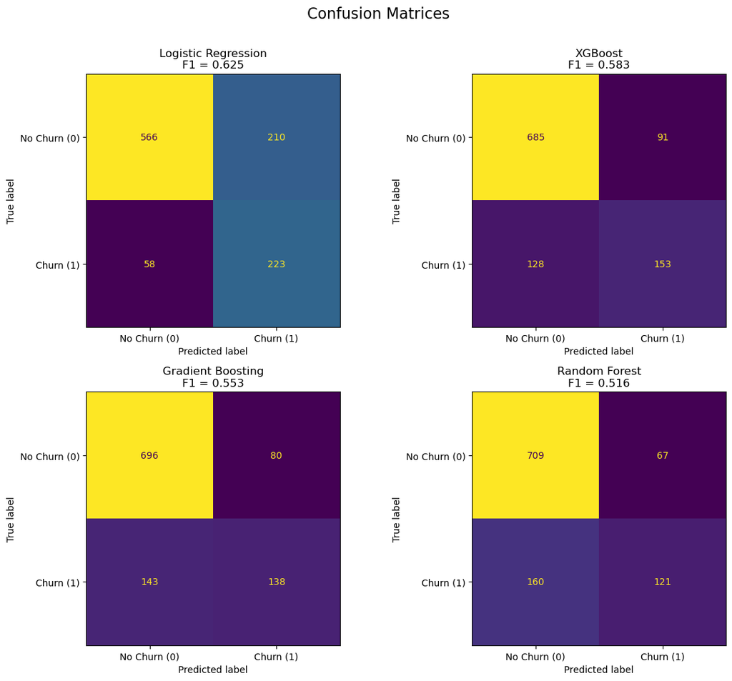

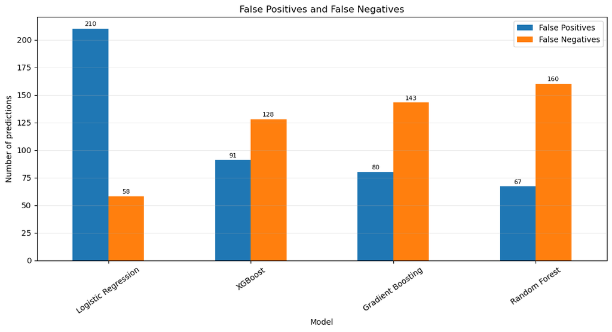

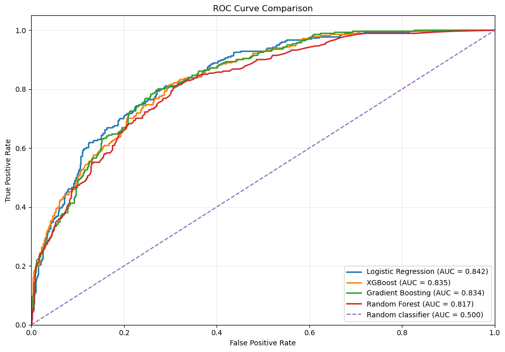

```python
model_specs = build_model_specs(random_state=42)

comparison = run_model_comparison(
    X_train=X_train,
    X_test=X_test,
    y_train=y_train,
    y_test=y_test,
    model_specs=model_specs,
)

display(comparison["results"].style.format({
    "Accuracy": "{:.3f}",
    "Precision": "{:.3f}",
    "Recall": "{:.3f}",
    "F1 Score": "{:.3f}",
    "ROC AUC": "{:.3f}",
}))

if not comparison["skipped_models"].empty:
    display(comparison["skipped_models"])

visualise_model_results(
    results=comparison["results"],
    confusion_summary=comparison["confusion_summary"],
    split_data=comparison["split_data"],
)
```

When comparing the models purely on their F1 scores, Logistic Regression performs best. One possible explanation is that the more complex models may be overfitting the training data, although we would need to compare training and validation performance to confirm this.

Interestingly, Logistic Regression produces more false positives than the other models but considerably fewer false negatives. This means it is more likely to incorrectly flag a customer as likely to churn, but it is also better at identifying customers who actually do churn.

We can also see that Logistic Regression performs slightly better on the ROC curve, further supporting its selection as our preferred model.

## Hyperparameter Tuning

Let’s use an LLM to help generate the Python code for hyperparameter tuning.

Logistic Regression will be tuned using grid search with five-fold stratified cross-validation. The search will evaluate L1 and L2 regularisation, a range of regularisation strengths, and several class-weighting schemes that place greater emphasis on churn cases. The different parameter combinations will be ranked using the F1 score.

Once the best hyperparameters have been selected, we will separately tune the classification threshold using out-of-fold training probabilities, choosing the threshold that maximises the F1 score.

```
=================================================================
BEST LOGISTIC REGRESSION HYPERPARAMETERS
=================================================================
C                   : 0.3
class_weight        : {0: 1, 1: 2.0}
penalty             : l1
solver              : liblinear

Best mean cross-validation F1: 0.6386
```

|  | param_C | param_penalty | param_class_weight | mean_test_score | std_test_score | mean_train_score | rank_test_score |
| --- | --- | --- | --- | --- | --- | --- | --- |
| 0 | 0.300000 | l1 | {0: 1, 1: 2.0} | 0.6386 | 0.0222 | 0.6378 | 1 |
| 1 | 1.000000 | l1 | {0: 1, 1: 2.0} | 0.6376 | 0.0226 | 0.6375 | 2 |
| 2 | 0.100000 | l1 | {0: 1, 1: 2.0} | 0.6376 | 0.0245 | 0.6377 | 3 |
| 3 | 1.000000 | l1 | {0: 1, 1: 1.75} | 0.6374 | 0.0222 | 0.6396 | 4 |
| 4 | 3.000000 | l2 | {0: 1, 1: 1.75} | 0.6372 | 0.0224 | 0.6390 | 5 |
| 5 | 0.300000 | l2 | {0: 1, 1: 2.0} | 0.6372 | 0.0228 | 0.6385 | 6 |
| 6 | 0.100000 | l2 | {0: 1, 1: 2.0} | 0.6371 | 0.0242 | 0.6397 | 7 |
| 7 | 1.000000 | l2 | {0: 1, 1: 2.0} | 0.6370 | 0.0231 | 0.6367 | 8 |
| 8 | 0.300000 | l1 | {0: 1, 1: 1.75} | 0.6368 | 0.0230 | 0.6399 | 9 |
| 9 | 3.000000 | l1 | {0: 1, 1: 1.75} | 0.6368 | 0.0228 | 0.6393 | 10 |
| 10 | 100.000000 | l2 | {0: 1, 1: 1.75} | 0.6368 | 0.0225 | 0.6389 | 11 |
| 11 | 3.000000 | l2 | {0: 1, 1: 2.0} | 0.6366 | 0.0234 | 0.6367 | 12 |
| 12 | 100.000000 | l1 | {0: 1, 1: 1.75} | 0.6365 | 0.0221 | 0.6389 | 13 |
| 13 | 30.000000 | l2 | {0: 1, 1: 1.75} | 0.6365 | 0.0221 | 0.6390 | 13 |
| 14 | 30.000000 | l1 | {0: 1, 1: 1.75} | 0.6365 | 0.0221 | 0.6391 | 13 |

```
=================================================================
OPTIMAL CLASSIFICATION THRESHOLD
=================================================================
Default threshold:             0.500
Optimal training threshold:    0.522
Out-of-fold F1 at threshold:   0.6405
Out-of-fold precision:         0.5676
Out-of-fold recall:            0.7347

=================================================================
FINAL TEST-SET COMPARISON
=================================================================
```

|  | Method | Accuracy | Precision | Recall | F1 Score | ROC AUC |
| --- | --- | --- | --- | --- | --- | --- |
| 0 | Default threshold (0.50) | 0.768 | 0.548 | 0.726 | 0.625 | 0.842 |
| 1 | Tuned threshold (0.522) | 0.779 | 0.567 | 0.705 | 0.629 | 0.842 |

```
=================================================================
TUNED LOGISTIC REGRESSION CLASSIFICATION REPORT
=================================================================
              precision    recall  f1-score   support

    No Churn      0.883     0.805     0.842       776
       Churn      0.567     0.705     0.629       281

    accuracy                          0.779      1057
   macro avg      0.725     0.755     0.735      1057
weighted avg      0.799     0.779     0.785      1057
```

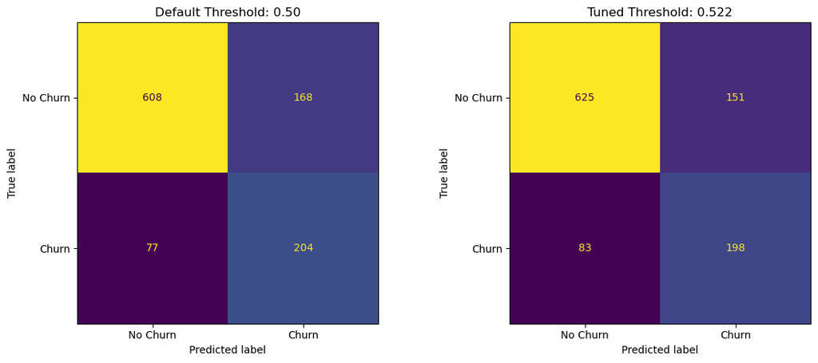

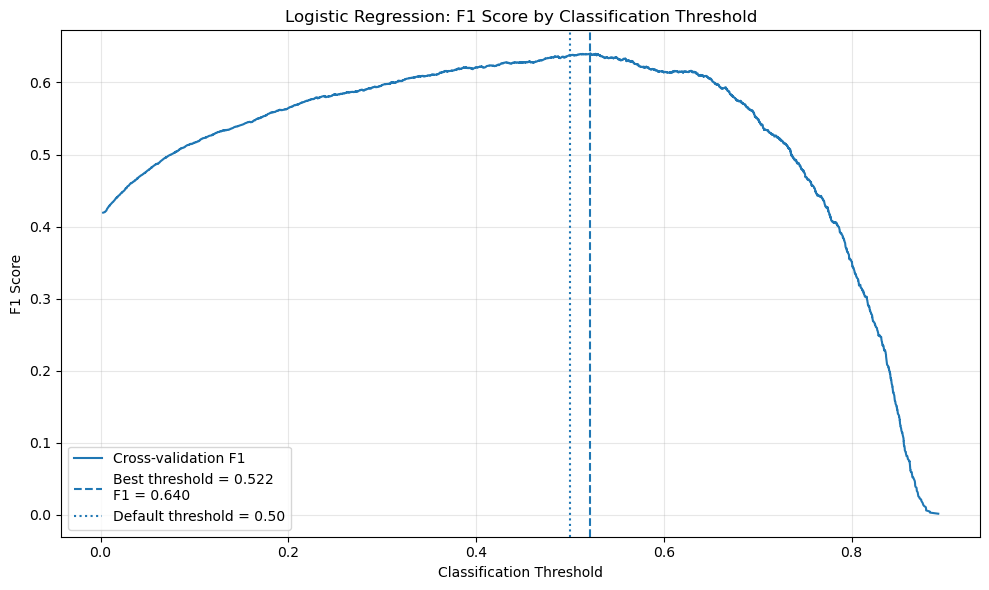

```python
# ============================================================
# HYPERPARAMETER AND THRESHOLD TUNING:
# LOGISTIC REGRESSION
# ============================================================

import numpy as np
import pandas as pd
import matplotlib.pyplot as plt

from sklearn.base import clone
from sklearn.linear_model import LogisticRegression
from sklearn.model_selection import (
    GridSearchCV,
    StratifiedKFold,
    cross_val_predict,
)
from sklearn.metrics import (
    classification_report,
    confusion_matrix,
    ConfusionMatrixDisplay,
    precision_recall_curve,
    precision_score,
    recall_score,
    f1_score,
    accuracy_score,
    roc_auc_score,
)


# ------------------------------------------------------------
# 1. Retrieve the existing train/test split
# ------------------------------------------------------------

X_train = comparison["split_data"]["X_train"]
X_test = comparison["split_data"]["X_test"]
y_train = comparison["split_data"]["y_train"]
y_test = comparison["split_data"]["y_test"]


# ------------------------------------------------------------
# 2. Cross-validation strategy
# ------------------------------------------------------------

cv = StratifiedKFold(
    n_splits=5,
    shuffle=True,
    random_state=42,
)


# ------------------------------------------------------------
# 3. Logistic Regression parameter grid
# ------------------------------------------------------------

logistic_model = LogisticRegression(
    max_iter=5000,
    random_state=42,
)

parameter_grid = {
    "solver": ["liblinear"],
    "penalty": ["l1", "l2"],
    "C": [
        0.001,
        0.003,
        0.01,
        0.03,
        0.1,
        0.3,
        1,
        3,
        10,
        30,
        100,
    ],
    "class_weight": [
        None,
        "balanced",
        {0: 1, 1: 1.25},
        {0: 1, 1: 1.5},
        {0: 1, 1: 1.75},
        {0: 1, 1: 2.0},
        {0: 1, 1: 2.5},
        {0: 1, 1: 3.0},
    ],
}


# ------------------------------------------------------------
# 4. Hyperparameter search
#
# scoring="f1" means the search maximizes F1 for class 1:
# customers who churn.
# ------------------------------------------------------------

grid_search = GridSearchCV(
    estimator=logistic_model,
    param_grid=parameter_grid,
    scoring="f1",
    cv=cv,
    n_jobs=-1,
    refit=True,
    return_train_score=True,
)

grid_search.fit(X_train, y_train)

print("=" * 65)
print("BEST LOGISTIC REGRESSION HYPERPARAMETERS")
print("=" * 65)

for parameter, value in grid_search.best_params_.items():
    print(f"{parameter:20}: {value}")

print(
    f"\nBest mean cross-validation F1: "
    f"{grid_search.best_score_:.4f}"
)


# ------------------------------------------------------------
# 5. Display the best cross-validation results
# ------------------------------------------------------------

cv_results = pd.DataFrame(grid_search.cv_results_)

cv_results = (
    cv_results[
        [
            "param_C",
            "param_penalty",
            "param_class_weight",
            "mean_test_score",
            "std_test_score",
            "mean_train_score",
            "rank_test_score",
        ]
    ]
    .sort_values("rank_test_score")
    .head(15)
    .reset_index(drop=True)
)

display(
    cv_results.style.format(
        {
            "mean_test_score": "{:.4f}",
            "std_test_score": "{:.4f}",
            "mean_train_score": "{:.4f}",
        }
    )
)


# ------------------------------------------------------------
# 6. Generate out-of-fold probabilities for threshold tuning
#
# This only uses the training data. The test data remains untouched.
# ------------------------------------------------------------

best_logistic_parameters = grid_search.best_params_

threshold_model = LogisticRegression(
    max_iter=5000,
    random_state=42,
    **best_logistic_parameters,
)

training_probabilities = cross_val_predict(
    threshold_model,
    X_train,
    y_train,
    cv=cv,
    method="predict_proba",
    n_jobs=-1,
)[:, 1]


# ------------------------------------------------------------
# 7. Find the threshold that maximizes F1
# ------------------------------------------------------------

precision_values, recall_values, thresholds = precision_recall_curve(
    y_train,
    training_probabilities,
)

# precision_recall_curve returns one more precision/recall value
# than threshold values, so remove the final unmatched values.
precision_for_thresholds = precision_values[:-1]
recall_for_thresholds = recall_values[:-1]

f1_values = (
    2
    * precision_for_thresholds
    * recall_for_thresholds
    / (
        precision_for_thresholds
        + recall_for_thresholds
        + 1e-12
    )
)

best_threshold_index = np.argmax(f1_values)

best_threshold = thresholds[best_threshold_index]
best_training_f1 = f1_values[best_threshold_index]

print("\n" + "=" * 65)
print("OPTIMAL CLASSIFICATION THRESHOLD")
print("=" * 65)

print(f"Default threshold:             0.500")
print(f"Optimal training threshold:    {best_threshold:.3f}")
print(f"Out-of-fold F1 at threshold:   {best_training_f1:.4f}")
print(
    f"Out-of-fold precision:         "
    f"{precision_for_thresholds[best_threshold_index]:.4f}"
)
print(
    f"Out-of-fold recall:            "
    f"{recall_for_thresholds[best_threshold_index]:.4f}"
)


# ------------------------------------------------------------
# 8. Fit the final tuned model on all training data
# ------------------------------------------------------------

final_logistic_model = LogisticRegression(
    max_iter=5000,
    random_state=42,
    **best_logistic_parameters,
)

final_logistic_model.fit(X_train, y_train)

test_probabilities = final_logistic_model.predict_proba(X_test)[:, 1]


# Predictions at the normal 0.50 threshold
predictions_default = (
    test_probabilities >= 0.50
).astype(int)

# Predictions at the tuned threshold
predictions_tuned = (
    test_probabilities >= best_threshold
).astype(int)


# ------------------------------------------------------------
# 9. Compare the default and tuned thresholds
# ------------------------------------------------------------

comparison_rows = []

for threshold_name, predictions in [
    ("Default threshold (0.50)", predictions_default),
    (
        f"Tuned threshold ({best_threshold:.3f})",
        predictions_tuned,
    ),
]:
    comparison_rows.append(
        {
            "Method": threshold_name,
            "Accuracy": accuracy_score(y_test, predictions),
            "Precision": precision_score(
                y_test,
                predictions,
                zero_division=0,
            ),
            "Recall": recall_score(
                y_test,
                predictions,
                zero_division=0,
            ),
            "F1 Score": f1_score(
                y_test,
                predictions,
                zero_division=0,
            ),
            "ROC AUC": roc_auc_score(
                y_test,
                test_probabilities,
            ),
        }
    )

tuned_results = pd.DataFrame(comparison_rows)

print("\n" + "=" * 65)
print("FINAL TEST-SET COMPARISON")
print("=" * 65)

display(
    tuned_results.style.format(
        {
            "Accuracy": "{:.3f}",
            "Precision": "{:.3f}",
            "Recall": "{:.3f}",
            "F1 Score": "{:.3f}",
            "ROC AUC": "{:.3f}",
        }
    )
)


# ------------------------------------------------------------
# 10. Classification report for the tuned model
# ------------------------------------------------------------

print("\n" + "=" * 65)
print("TUNED LOGISTIC REGRESSION CLASSIFICATION REPORT")
print("=" * 65)

print(
    classification_report(
        y_test,
        predictions_tuned,
        target_names=["No Churn", "Churn"],
        digits=3,
    )
)


# ------------------------------------------------------------
# 11. Confusion matrices
# ------------------------------------------------------------

default_matrix = confusion_matrix(
    y_test,
    predictions_default,
    labels=[0, 1],
)

tuned_matrix = confusion_matrix(
    y_test,
    predictions_tuned,
    labels=[0, 1],
)

fig, axes = plt.subplots(
    1,
    2,
    figsize=(12, 5),
)

ConfusionMatrixDisplay(
    confusion_matrix=default_matrix,
    display_labels=["No Churn", "Churn"],
).plot(
    ax=axes[0],
    values_format="d",
    colorbar=False,
)

axes[0].set_title("Default Threshold: 0.50")

ConfusionMatrixDisplay(
    confusion_matrix=tuned_matrix,
    display_labels=["No Churn", "Churn"],
).plot(
    ax=axes[1],
    values_format="d",
    colorbar=False,
)

axes[1].set_title(
    f"Tuned Threshold: {best_threshold:.3f}"
)

plt.tight_layout()
plt.show()


# ------------------------------------------------------------
# 12. Plot F1 against classification threshold
# ------------------------------------------------------------

plt.figure(figsize=(10, 6))

plt.plot(
    thresholds,
    f1_values,
    label="Cross-validation F1",
)

plt.axvline(
    best_threshold,
    linestyle="--",
    label=(
        f"Best threshold = {best_threshold:.3f}\n"
        f"F1 = {best_training_f1:.3f}"
    ),
)

plt.axvline(
    0.50,
    linestyle=":",
    label="Default threshold = 0.50",
)

plt.xlabel("Classification Threshold")
plt.ylabel("F1 Score")
plt.title(
    "Logistic Regression: F1 Score by Classification Threshold"
)
plt.legend()
plt.grid(alpha=0.3)
plt.tight_layout()
plt.show()
```

We can see that the optimal classification threshold is close to the original value of 0.5, with a relatively broad plateau around this point. This suggests that model performance is not especially sensitive to small changes in the threshold.

## Conclusion

If we were applying this model in a business dashboard, we would recommend using the Logistic Regression classification model to identify customers who are most likely to churn. The dashboard could display each customer’s predicted probability of churn, allowing the business to prioritise customers at the greatest risk.Based on our analysis, higher-risk customers are typically those with low tenure, no long-term contract, and a fibre-optic internet service. This could also prompt the business to investigate the fibre-optic service, pricing, or customer experience to understand why these customers appear more likely to leave.

Finally, the business could monitor these relationships over time. This would help determine whether changes to products, pricing, contracts, or retention initiatives reduce the association between these factors and customer churn.